# Risk Factor Analysis

## Outcome Variable

**Outcome Variable:** stunted

## Predictor Variables

**Intervention Variable:** fhtcm

**Adjustment Set:**

unadjusted

## Stratifying Variables

The analysis was stratified on these variable(s):

- agecat
- studyid
- country

## Data Summary

| agecat | studyid | country | fhtcm | stunted | n_cell | n |
| --- | --- | --- | --- | --- | --- | --- |
| 6 months | ki1000304b-SAS-CompFeed | INDIA | [160-170) | 0 | 328 | 807 |
| 6 months | ki1000304b-SAS-CompFeed | INDIA | [160-170) | 1 | 134 | 807 |
| 6 months | ki1000304b-SAS-CompFeed | INDIA | <160 | 0 | 71 | 807 |
| 6 months | ki1000304b-SAS-CompFeed | INDIA | <160 | 1 | 43 | 807 |
| 6 months | ki1000304b-SAS-CompFeed | INDIA | >=170 | 0 | 179 | 807 |
| 6 months | ki1000304b-SAS-CompFeed | INDIA | >=170 | 1 | 52 | 807 |
| Birth | ki1000304b-SAS-CompFeed | INDIA | [160-170) | 0 | 50 | 102 |
| Birth | ki1000304b-SAS-CompFeed | INDIA | [160-170) | 1 | 15 | 102 |
| Birth | ki1000304b-SAS-CompFeed | INDIA | <160 | 0 | 7 | 102 |
| Birth | ki1000304b-SAS-CompFeed | INDIA | <160 | 1 | 4 | 102 |
| Birth | ki1000304b-SAS-CompFeed | INDIA | >=170 | 0 | 18 | 102 |
| Birth | ki1000304b-SAS-CompFeed | INDIA | >=170 | 1 | 8 | 102 |
| 6 months | ki1000304b-SAS-FoodSuppl | INDIA | [160-170) | 0 | 135 | 372 |
| 6 months | ki1000304b-SAS-FoodSuppl | INDIA | [160-170) | 1 | 90 | 372 |
| 6 months | ki1000304b-SAS-FoodSuppl | INDIA | <160 | 0 | 45 | 372 |
| 6 months | ki1000304b-SAS-FoodSuppl | INDIA | <160 | 1 | 49 | 372 |
| 6 months | ki1000304b-SAS-FoodSuppl | INDIA | >=170 | 0 | 33 | 372 |
| 6 months | ki1000304b-SAS-FoodSuppl | INDIA | >=170 | 1 | 20 | 372 |
| Birth | ki1101329-Keneba | GAMBIA | [160-170) | 0 | 598 | 1165 |
| Birth | ki1101329-Keneba | GAMBIA | [160-170) | 1 | 33 | 1165 |
| Birth | ki1101329-Keneba | GAMBIA | <160 | 0 | 24 | 1165 |
| Birth | ki1101329-Keneba | GAMBIA | <160 | 1 | 3 | 1165 |
| Birth | ki1101329-Keneba | GAMBIA | >=170 | 0 | 485 | 1165 |
| Birth | ki1101329-Keneba | GAMBIA | >=170 | 1 | 22 | 1165 |
| 6 months | ki1101329-Keneba | GAMBIA | [160-170) | 0 | 692 | 1511 |
| 6 months | ki1101329-Keneba | GAMBIA | [160-170) | 1 | 136 | 1511 |
| 6 months | ki1101329-Keneba | GAMBIA | <160 | 0 | 29 | 1511 |
| 6 months | ki1101329-Keneba | GAMBIA | <160 | 1 | 5 | 1511 |
| 6 months | ki1101329-Keneba | GAMBIA | >=170 | 0 | 581 | 1511 |
| 6 months | ki1101329-Keneba | GAMBIA | >=170 | 1 | 68 | 1511 |
| 24 months | ki1101329-Keneba | GAMBIA | [160-170) | 0 | 428 | 1297 |
| 24 months | ki1101329-Keneba | GAMBIA | [160-170) | 1 | 301 | 1297 |
| 24 months | ki1101329-Keneba | GAMBIA | <160 | 0 | 15 | 1297 |
| 24 months | ki1101329-Keneba | GAMBIA | <160 | 1 | 12 | 1297 |
| 24 months | ki1101329-Keneba | GAMBIA | >=170 | 0 | 405 | 1297 |
| 24 months | ki1101329-Keneba | GAMBIA | >=170 | 1 | 136 | 1297 |
| Birth | ki1119695-PROBIT | BELARUS | [160-170) | 0 | 1384 | 12533 |
| Birth | ki1119695-PROBIT | BELARUS | [160-170) | 1 | 3 | 12533 |
| Birth | ki1119695-PROBIT | BELARUS | <160 | 0 | 54 | 12533 |
| Birth | ki1119695-PROBIT | BELARUS | <160 | 1 | 0 | 12533 |
| Birth | ki1119695-PROBIT | BELARUS | >=170 | 0 | 11066 | 12533 |
| Birth | ki1119695-PROBIT | BELARUS | >=170 | 1 | 26 | 12533 |
| 6 months | ki1119695-PROBIT | BELARUS | [160-170) | 0 | 1169 | 11895 |
| 6 months | ki1119695-PROBIT | BELARUS | [160-170) | 1 | 137 | 11895 |
| 6 months | ki1119695-PROBIT | BELARUS | <160 | 0 | 43 | 11895 |
| 6 months | ki1119695-PROBIT | BELARUS | <160 | 1 | 9 | 11895 |
| 6 months | ki1119695-PROBIT | BELARUS | >=170 | 0 | 9983 | 11895 |
| 6 months | ki1119695-PROBIT | BELARUS | >=170 | 1 | 554 | 11895 |
| 24 months | ki1119695-PROBIT | BELARUS | [160-170) | 0 | 331 | 3670 |
| 24 months | ki1119695-PROBIT | BELARUS | [160-170) | 1 | 56 | 3670 |
| 24 months | ki1119695-PROBIT | BELARUS | <160 | 0 | 17 | 3670 |
| 24 months | ki1119695-PROBIT | BELARUS | <160 | 1 | 5 | 3670 |
| 24 months | ki1119695-PROBIT | BELARUS | >=170 | 0 | 3004 | 3670 |
| 24 months | ki1119695-PROBIT | BELARUS | >=170 | 1 | 257 | 3670 |
| 6 months | ki1135781-COHORTS | GUATEMALA | [160-170) | 0 | 99 | 336 |
| 6 months | ki1135781-COHORTS | GUATEMALA | [160-170) | 1 | 69 | 336 |
| 6 months | ki1135781-COHORTS | GUATEMALA | <160 | 0 | 63 | 336 |
| 6 months | ki1135781-COHORTS | GUATEMALA | <160 | 1 | 82 | 336 |
| 6 months | ki1135781-COHORTS | GUATEMALA | >=170 | 0 | 18 | 336 |
| 6 months | ki1135781-COHORTS | GUATEMALA | >=170 | 1 | 5 | 336 |
| 24 months | ki1135781-COHORTS | GUATEMALA | [160-170) | 0 | 56 | 528 |
| 24 months | ki1135781-COHORTS | GUATEMALA | [160-170) | 1 | 198 | 528 |
| 24 months | ki1135781-COHORTS | GUATEMALA | <160 | 0 | 42 | 528 |
| 24 months | ki1135781-COHORTS | GUATEMALA | <160 | 1 | 191 | 528 |
| 24 months | ki1135781-COHORTS | GUATEMALA | >=170 | 0 | 20 | 528 |
| 24 months | ki1135781-COHORTS | GUATEMALA | >=170 | 1 | 21 | 528 |
| Birth | ki1135781-COHORTS | GUATEMALA | [160-170) | 0 | 93 | 206 |
| Birth | ki1135781-COHORTS | GUATEMALA | [160-170) | 1 | 7 | 206 |
| Birth | ki1135781-COHORTS | GUATEMALA | <160 | 0 | 86 | 206 |
| Birth | ki1135781-COHORTS | GUATEMALA | <160 | 1 | 6 | 206 |
| Birth | ki1135781-COHORTS | GUATEMALA | >=170 | 0 | 12 | 206 |
| Birth | ki1135781-COHORTS | GUATEMALA | >=170 | 1 | 2 | 206 |

The following strata were considered:

- agecat: 24 months, studyid: ki1101329-Keneba, country: GAMBIA
- agecat: 24 months, studyid: ki1119695-PROBIT, country: BELARUS
- agecat: 24 months, studyid: ki1135781-COHORTS, country: GUATEMALA
- agecat: 6 months, studyid: ki1000304b-SAS-CompFeed, country: INDIA
- agecat: 6 months, studyid: ki1000304b-SAS-FoodSuppl, country: INDIA
- agecat: 6 months, studyid: ki1101329-Keneba, country: GAMBIA
- agecat: 6 months, studyid: ki1119695-PROBIT, country: BELARUS
- agecat: 6 months, studyid: ki1135781-COHORTS, country: GUATEMALA
- agecat: Birth, studyid: ki1000304b-SAS-CompFeed, country: INDIA
- agecat: Birth, studyid: ki1101329-Keneba, country: GAMBIA
- agecat: Birth, studyid: ki1119695-PROBIT, country: BELARUS
- agecat: Birth, studyid: ki1135781-COHORTS, country: GUATEMALA

### Dropped Strata

Some strata were dropped due to rare outcomes:

- agecat: Birth, studyid: ki1000304b-SAS-CompFeed, country: INDIA
- agecat: Birth, studyid: ki1101329-Keneba, country: GAMBIA
- agecat: Birth, studyid: ki1119695-PROBIT, country: BELARUS
- agecat: Birth, studyid: ki1135781-COHORTS, country: GUATEMALA

## Methods Detail

We’re interested in the causal parameters $E[Y_a]$ for all values of $a \in \mathcal{A}$. These parameters represent the mean outcome if, possibly contrary to fact, we intervened to set all units to have $A=a$. Under the randomization and positivity assumptions, these are identified by the statistical parameters $\psi_a=E_W[E_{Y|A,W}(Y|A=a,W)]$. In addition, we’re interested in the mean of $Y$, $E[Y]$ under no intervention (the observed mean). We will estimate these parameters by using SuperLearner to fit the relevant likelihood factors – $E_{Y|A,W}(Y|A=a,W)$ and $p(A=a|W)$, and then updating our likelihood fit using a joint TMLE.

For unadjusted analyses ($W=\{\}$), initial likelihoods were estimated using Lrnr_glm to estimate the simple $E(Y|A)$ and Lrnr_mean to estimate $p(A)$. For adjusted analyses, a small library containing Lrnr_glmnet, Lrnr_xgboost, and Lrnr_mean was used.

Having estimated these parameters, we will then use the delta method to estimate relative risks and attributable risks relative to a prespecified baseline level of $A$.

# Results Detail

## Results Plots

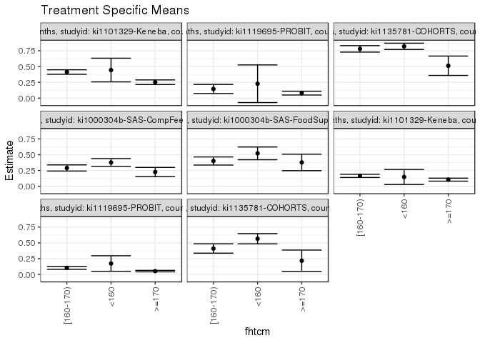

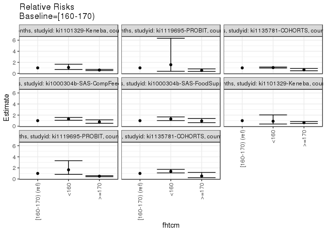

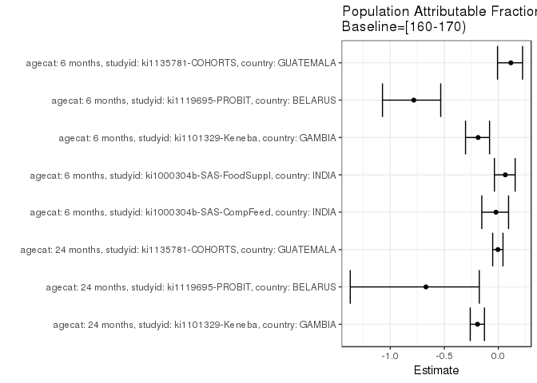

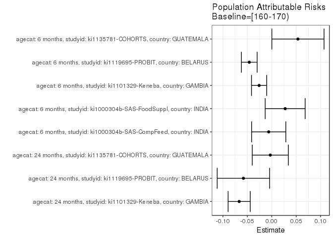

## Results Table

### Parameter: TSM

| agecat | studyid | country | intervention_level | baseline_level | estimate | ci_lower | ci_upper |
| --- | --- | --- | --- | --- | --- | --- | --- |
| 6 months | ki1000304b-SAS-CompFeed | INDIA | [160-170) | NA | 0.2900433 | 0.2412683 | 0.3388183 |
| 6 months | ki1000304b-SAS-CompFeed | INDIA | <160 | NA | 0.3771930 | 0.3156484 | 0.4387375 |
| 6 months | ki1000304b-SAS-CompFeed | INDIA | >=170 | NA | 0.2251082 | 0.1516721 | 0.2985444 |
| 6 months | ki1000304b-SAS-FoodSuppl | INDIA | [160-170) | NA | 0.4000000 | 0.3359016 | 0.4640984 |
| 6 months | ki1000304b-SAS-FoodSuppl | INDIA | <160 | NA | 0.5212766 | 0.4201547 | 0.6223985 |
| 6 months | ki1000304b-SAS-FoodSuppl | INDIA | >=170 | NA | 0.3773585 | 0.2466840 | 0.5080330 |
| 6 months | ki1101329-Keneba | GAMBIA | [160-170) | NA | 0.1642512 | 0.1390066 | 0.1894958 |
| 6 months | ki1101329-Keneba | GAMBIA | <160 | NA | 0.1470588 | 0.0279737 | 0.2661439 |
| 6 months | ki1101329-Keneba | GAMBIA | >=170 | NA | 0.1047766 | 0.0812062 | 0.1283470 |
| 6 months | ki1119695-PROBIT | BELARUS | [160-170) | NA | 0.1049005 | 0.0812931 | 0.1285078 |
| 6 months | ki1119695-PROBIT | BELARUS | <160 | NA | 0.1730769 | 0.0500252 | 0.2961287 |
| 6 months | ki1119695-PROBIT | BELARUS | >=170 | NA | 0.0525766 | 0.0409079 | 0.0642454 |
| 6 months | ki1135781-COHORTS | GUATEMALA | [160-170) | NA | 0.4107143 | 0.3362113 | 0.4852172 |
| 6 months | ki1135781-COHORTS | GUATEMALA | <160 | NA | 0.5655172 | 0.4847155 | 0.6463189 |
| 6 months | ki1135781-COHORTS | GUATEMALA | >=170 | NA | 0.2173913 | 0.0485709 | 0.3862117 |
| 24 months | ki1101329-Keneba | GAMBIA | [160-170) | NA | 0.4128944 | 0.3771400 | 0.4486488 |
| 24 months | ki1101329-Keneba | GAMBIA | <160 | NA | 0.4444444 | 0.2569423 | 0.6319466 |
| 24 months | ki1101329-Keneba | GAMBIA | >=170 | NA | 0.2513863 | 0.2148170 | 0.2879556 |
| 24 months | ki1119695-PROBIT | BELARUS | [160-170) | NA | 0.1447028 | 0.0727636 | 0.2166421 |
| 24 months | ki1119695-PROBIT | BELARUS | <160 | NA | 0.2272727 | -0.0707084 | 0.5252538 |
| 24 months | ki1119695-PROBIT | BELARUS | >=170 | NA | 0.0788102 | 0.0487723 | 0.1088480 |
| 24 months | ki1135781-COHORTS | GUATEMALA | [160-170) | NA | 0.7795276 | 0.7284964 | 0.8305588 |
| 24 months | ki1135781-COHORTS | GUATEMALA | <160 | NA | 0.8197425 | 0.7703379 | 0.8691471 |
| 24 months | ki1135781-COHORTS | GUATEMALA | >=170 | NA | 0.5121951 | 0.3590481 | 0.6653422 |

### Parameter: E(Y)

| agecat | studyid | country | intervention_level | baseline_level | estimate | ci_lower | ci_upper |
| --- | --- | --- | --- | --- | --- | --- | --- |
| 6 months | ki1000304b-SAS-CompFeed | INDIA | NA | NA | 0.2837670 | 0.2471555 | 0.3203786 |
| 6 months | ki1000304b-SAS-FoodSuppl | INDIA | NA | NA | 0.4274194 | 0.3770801 | 0.4777586 |
| 6 months | ki1101329-Keneba | GAMBIA | NA | NA | 0.1383190 | 0.1209060 | 0.1557320 |
| 6 months | ki1119695-PROBIT | BELARUS | NA | NA | 0.0588483 | 0.0462144 | 0.0714821 |
| 6 months | ki1135781-COHORTS | GUATEMALA | NA | NA | 0.4642857 | 0.4108803 | 0.5176911 |
| 24 months | ki1101329-Keneba | GAMBIA | NA | NA | 0.3461835 | 0.3202819 | 0.3720851 |
| 24 months | ki1119695-PROBIT | BELARUS | NA | NA | 0.0866485 | 0.0534930 | 0.1198040 |
| 24 months | ki1135781-COHORTS | GUATEMALA | NA | NA | 0.7765152 | 0.7409486 | 0.8120817 |

### Parameter: RR

| agecat | studyid | country | intervention_level | baseline_level | estimate | ci_lower | ci_upper |
| --- | --- | --- | --- | --- | --- | --- | --- |
| 6 months | ki1000304b-SAS-CompFeed | INDIA | [160-170) | [160-170) | 1.0000000 | 1.0000000 | 1.0000000 |
| 6 months | ki1000304b-SAS-CompFeed | INDIA | <160 | [160-170) | 1.3004713 | 1.0722047 | 1.5773347 |
| 6 months | ki1000304b-SAS-CompFeed | INDIA | >=170 | [160-170) | 0.7761194 | 0.5232293 | 1.1512378 |
| 6 months | ki1000304b-SAS-FoodSuppl | INDIA | [160-170) | [160-170) | 1.0000000 | 1.0000000 | 1.0000000 |
| 6 months | ki1000304b-SAS-FoodSuppl | INDIA | <160 | [160-170) | 1.3031915 | 1.0132881 | 1.6760367 |
| 6 months | ki1000304b-SAS-FoodSuppl | INDIA | >=170 | [160-170) | 0.9433962 | 0.6441418 | 1.3816777 |
| 6 months | ki1101329-Keneba | GAMBIA | [160-170) | [160-170) | 1.0000000 | 1.0000000 | 1.0000000 |
| 6 months | ki1101329-Keneba | GAMBIA | <160 | [160-170) | 0.8953287 | 0.3926645 | 2.0414717 |
| 6 months | ki1101329-Keneba | GAMBIA | >=170 | [160-170) | 0.6379045 | 0.4857719 | 0.8376815 |
| 6 months | ki1119695-PROBIT | BELARUS | [160-170) | [160-170) | 1.0000000 | 1.0000000 | 1.0000000 |
| 6 months | ki1119695-PROBIT | BELARUS | <160 | [160-170) | 1.6499158 | 0.8253416 | 3.2982974 |
| 6 months | ki1119695-PROBIT | BELARUS | >=170 | [160-170) | 0.5012050 | 0.4168644 | 0.6026094 |
| 6 months | ki1135781-COHORTS | GUATEMALA | [160-170) | [160-170) | 1.0000000 | 1.0000000 | 1.0000000 |
| 6 months | ki1135781-COHORTS | GUATEMALA | <160 | [160-170) | 1.3769115 | 1.0930051 | 1.7345623 |
| 6 months | ki1135781-COHORTS | GUATEMALA | >=170 | [160-170) | 0.5293006 | 0.2384305 | 1.1750136 |
| 24 months | ki1101329-Keneba | GAMBIA | [160-170) | [160-170) | 1.0000000 | 1.0000000 | 1.0000000 |
| 24 months | ki1101329-Keneba | GAMBIA | <160 | [160-170) | 1.0764120 | 0.6997431 | 1.6558401 |
| 24 months | ki1101329-Keneba | GAMBIA | >=170 | [160-170) | 0.6088393 | 0.5140193 | 0.7211505 |
| 24 months | ki1119695-PROBIT | BELARUS | [160-170) | [160-170) | 1.0000000 | 1.0000000 | 1.0000000 |
| 24 months | ki1119695-PROBIT | BELARUS | <160 | [160-170) | 1.5706169 | 0.3886452 | 6.3472735 |
| 24 months | ki1119695-PROBIT | BELARUS | >=170 | [160-170) | 0.5446346 | 0.3609301 | 0.8218404 |
| 24 months | ki1135781-COHORTS | GUATEMALA | [160-170) | [160-170) | 1.0000000 | 1.0000000 | 1.0000000 |
| 24 months | ki1135781-COHORTS | GUATEMALA | <160 | [160-170) | 1.0515888 | 0.9620584 | 1.1494511 |
| 24 months | ki1135781-COHORTS | GUATEMALA | >=170 | [160-170) | 0.6570584 | 0.4838084 | 0.8923486 |

### Parameter: PAR

| agecat | studyid | country | intervention_level | baseline_level | estimate | ci_lower | ci_upper |
| --- | --- | --- | --- | --- | --- | --- | --- |
| 6 months | ki1000304b-SAS-CompFeed | INDIA | [160-170) | NA | -0.0062763 | -0.0412758 | 0.0287233 |
| 6 months | ki1000304b-SAS-FoodSuppl | INDIA | [160-170) | NA | 0.0274194 | -0.0134776 | 0.0683163 |
| 6 months | ki1101329-Keneba | GAMBIA | [160-170) | NA | -0.0259322 | -0.0414904 | -0.0103740 |
| 6 months | ki1119695-PROBIT | BELARUS | [160-170) | NA | -0.0460522 | -0.0621676 | -0.0299368 |
| 6 months | ki1135781-COHORTS | GUATEMALA | [160-170) | NA | 0.0535714 | 0.0001661 | 0.1069768 |
| 24 months | ki1101329-Keneba | GAMBIA | [160-170) | NA | -0.0667109 | -0.0893428 | -0.0440789 |
| 24 months | ki1119695-PROBIT | BELARUS | [160-170) | NA | -0.0580543 | -0.1116912 | -0.0044175 |
| 24 months | ki1135781-COHORTS | GUATEMALA | [160-170) | NA | -0.0030124 | -0.0399397 | 0.0339149 |

### Parameter: PAF

| agecat | studyid | country | intervention_level | baseline_level | estimate | ci_lower | ci_upper |
| --- | --- | --- | --- | --- | --- | --- | --- |
| 6 months | ki1000304b-SAS-CompFeed | INDIA | [160-170) | NA | -0.0221176 | -0.1534782 | 0.0942833 |
| 6 months | ki1000304b-SAS-FoodSuppl | INDIA | [160-170) | NA | 0.0641509 | -0.0367260 | 0.1552123 |
| 6 months | ki1101329-Keneba | GAMBIA | [160-170) | NA | -0.1874812 | -0.3037660 | -0.0815680 |
| 6 months | ki1119695-PROBIT | BELARUS | [160-170) | NA | -0.7825585 | -1.0722120 | -0.5333928 |
| 6 months | ki1135781-COHORTS | GUATEMALA | [160-170) | NA | 0.1153846 | -0.0079202 | 0.2236048 |
| 24 months | ki1101329-Keneba | GAMBIA | [160-170) | NA | -0.1927038 | -0.2603447 | -0.1286931 |
| 24 months | ki1119695-PROBIT | BELARUS | [160-170) | NA | -0.6699982 | -1.3701640 | -0.1766671 |
| 24 months | ki1135781-COHORTS | GUATEMALA | [160-170) | NA | -0.0038794 | -0.0525810 | 0.0425688 |